# What to do in Hamburg

# **Activities in Hamburg**

Hamburg offers many places to relax, discover and celebrate. Here are a few selected places that are absolutely recommendable if you are new to Hamburg.

## **Outdoor**

**Planten un Bloomen**

**Where**: Marseiller Promenade, 20355 Hamburg, near U Bahn Stephansplatz, S Bahn Dammtor

**Activities**: Walking, relaxing, concerts

The public park near the main campus offers 47 ha of numerous places to walk and relax and leads through various botanical worlds, such as the Japanese park. Tropical plants are also on display and can be viewed in greenhouses. Concerts and other cultural events are also held here seasonally.

**Alster**

**Where:** U Bahn Jungfernstieg and Hauptbahnhof

**Activities**: Walking, sailing, SUP, pedal boating

The Alster is one of three rivers that flow through Hamburg. From the underground station Jungfernstieg you can quickly walk from the so-called Binnenalster to the Außenalster. It takes about 2 hours to walk completely around it or you can also discover the Alster on the water, e.g. from a sailing boat, pedal boat or SUP.

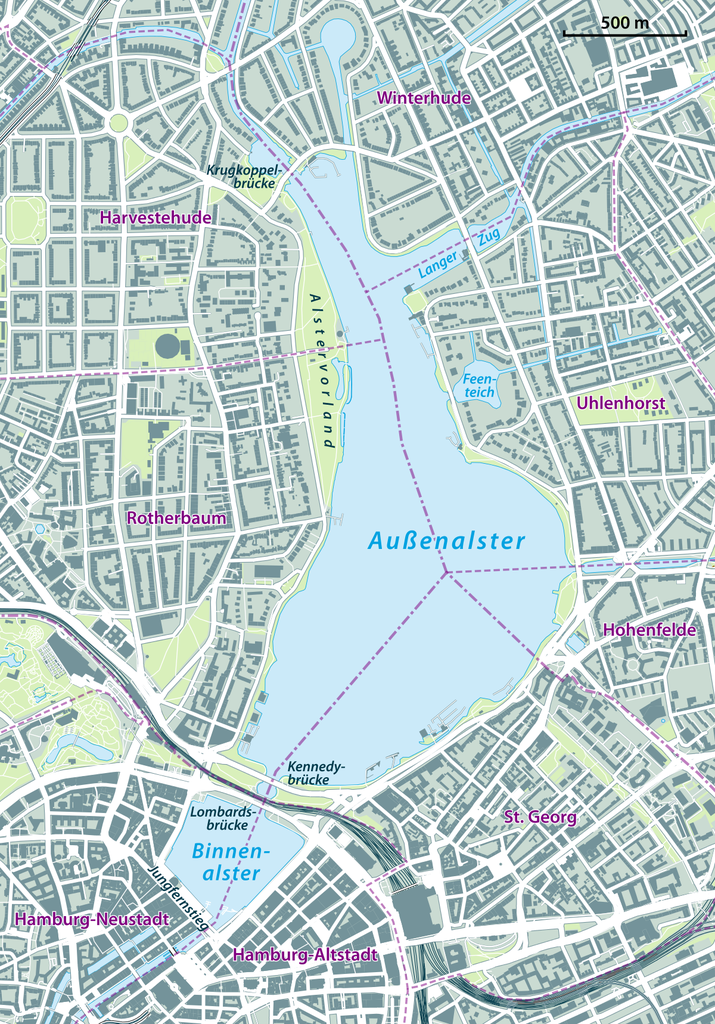

© wikipedia

**Altonaer Balkon and Elbstrand**

**Where**: S Bahn Königstraße, Ferry 62 or Bus 111 to Övelgönne

**Activities**: Walking, various outdoor activities, cocktails, …

From our institute you can reach the Altonaer Balkon in a few minutes, from where you have a great view of the Hamburg harbour, Dockland and the waterway. You can walk or take public transport from here to the museum harbour Övelgönne and the Elbe beach. Here, in addition to historic ships, you can also discover several bars and restaurants located next to the beach. The “Strandperle” bar is particularly well-known and very popular with locals and tourists.

## **Bars**

**Aurel**

**Where**: Bahrenfelder Str. 157, 22765 Hamburg, S Bahn Altona

**What:** A fun and hip bar with friendly interior, snacks, and a selection of cocktails as well as outdoor seating.

**Altes Mädchen**

**Where**: Lagerstraße 28b, 20357 Hamburg, S Bahn Sternschanze

**What**: The Braugasthaus offers good beer from its own brewery and home-style brewhouse cuisine, plus a cosy flair in an otherwise very lively district, the Schanzenviertel.

**Goldfischglas**

**Where**: Bartelsstraße 30, 20357 Hamburg, S Bahn Sternschanze

**What**: Cocktails and draught beer in a bar with a casual ambience, DJs and a compact dance floor.

**Zum tanzenden Einhorn**

**Where**: Hammer Steindamm 108, 20535 Hamburg, U Bahn Hammer Kirche

**What**: Medieval tavern with warm cuisine and delicious drinks. A real Hamburg original even for non-nerds (but also for nerds).

## **Sports**

The university offers a variety of sports courses on their website: [Hochschulsport](https://www.hochschulsport.uni-hamburg.de/). The courses change each semester, new courses usually start in April and October. You can attend over 100 different courses with the Flexicard, but for some courses you have to book a slot for each week. The Flexicard can be purchased for 3 or for 6 months. The courses which you can attend with the Flexicard are marked with a ♥ on the [Hochschulsport](https://www.hochschulsport.uni-hamburg.de/) website. All other courses can be booked individually. These courses run usually one semester.

The Hochschulsport offers also skiing or snowboard camps and in summer surfing and kitesurfing camps.

A highlight that Hamburg and the Hochschulsport have to offer are the many different water sports such as sailing, kayaking, rowing and kanupolo.

## Cinemas

Many cinemas in Hamburg show films in English or the original language (often with German subtitles). In the programs they have the note OmU (original with subtitles). Here is a lst of cinemas, where you have the best chances of finding movies in original language (but big cinemas like Cinemaxx occasionally also have some):

**Abaton Kino**

Allendeplatz 3 / Ecke Grindelhof, 20146 Hamburg

**FilmRaum**

Müggenkampstraße 45, 20257 Hamburg

**Lichtmess Kino**

Gausstraße 25, 22765 Hamburg

**Metropolis Kino**

Kleine Theaterstraße 10, 20354 Hamburg

**Savoy Filmtheater**

Steindamm 54, 20099 Hamburg

The Savoy also has a Sneak Preview in English.

**Studio Kino**

Bernstorffstraße 93 - 95, 22767 Hamburg